# Let's Build a Web App to Design Titanic Passengers - Walthrough of Chapter 3 from My Book Monetizing Machine Learning

**Resources**

- YouTube Companion Video

# Let's Build a Web App to Design Titanic Passengers - Walthrough of Chapter 3 from My Book Monetizing Machine Learning

[figure not shown]

Let's build an interactive web application to design fictional titanic passengers and see how they would've fared. The approach I describe in this book is all about extending python data science models into fully interactive web applications. No native mobile programming, no permissions, and no complicated jupyter knowledge or tableau for the world to enjoy your work.

# Surviving the Titanic Shipwreck - Experiment with Passenger Profiles

Note: you can install the requirements file for this notebook if you want to install all the libraries at once. Open a new terminal window, navigate to the folder with the "requirements_jupyter.txt" and run the following command:

*pip3 install -r requirements_jupyter.txt*

```python
#!/usr/bin/env python
import matplotlib.pyplot as plt; plt.rcdefaults()
import pandas as pd
import numpy as np
from sklearn.linear_model import LogisticRegression
from sklearn.model_selection import train_test_split
from numpy import genfromtxt
from sklearn.feature_selection import RFE
```

```python
# download the data from the Vanderbilt University Department of Biostatistics servers
# if you cannot download the files try doing it manually
# if have an ssl error  Mac try fix: "/Applications/Python\ 3.6/Install\ Certificates.command"
titanic_df = pd.read_csv('http://biostat.mc.vanderbilt.edu/wiki/pub/Main/DataSets/titanic3.csv')
```

```python
# take a peek at the data
titanic_df.head()
```

|  | pclass | survived | name | sex | age | sibsp | parch | ticket | fare | cabin | embarked | boat | body | home.dest |
| --- | --- | --- | --- | --- | --- | --- | --- | --- | --- | --- | --- | --- | --- | --- |
| 0 | 1 | 1 | Allen, Miss. Elisabeth Walton | female | 29.00 | 0 | 0 | 24160 | 211.3375 | B5 | S | 2 | NaN | St Louis, MO |
| 1 | 1 | 1 | Allison, Master. Hudson Trevor | male | 0.92 | 1 | 2 | 113781 | 151.5500 | C22 C26 | S | 11 | NaN | Montreal, PQ / Chesterville, ON |
| 2 | 1 | 0 | Allison, Miss. Helen Loraine | female | 2.00 | 1 | 2 | 113781 | 151.5500 | C22 C26 | S | NaN | NaN | Montreal, PQ / Chesterville, ON |
| 3 | 1 | 0 | Allison, Mr. Hudson Joshua Creighton | male | 30.00 | 1 | 2 | 113781 | 151.5500 | C22 C26 | S | NaN | 135.0 | Montreal, PQ / Chesterville, ON |
| 4 | 1 | 0 | Allison, Mrs. Hudson J C (Bessie Waldo Daniels) | female | 25.00 | 1 | 2 | 113781 | 151.5500 | C22 C26 | S | NaN | NaN | Montreal, PQ / Chesterville, ON |

```python
titanic_df['embarked'].value_counts()
```

```
S    914
C    270
Q    123
Name: embarked, dtype: int64
```

# Data Exploration

```python
# feature data types
titanic_df.info()
```

```
<class 'pandas.core.frame.DataFrame'>
RangeIndex: 1309 entries, 0 to 1308
Data columns (total 14 columns):
pclass       1309 non-null int64
survived     1309 non-null int64
name         1309 non-null object
sex          1309 non-null object
age          1046 non-null float64
sibsp        1309 non-null int64
parch        1309 non-null int64
ticket       1309 non-null object
fare         1308 non-null float64
cabin        295 non-null object
embarked     1307 non-null object
boat         486 non-null object
body         121 non-null float64
home.dest    745 non-null object
dtypes: float64(3), int64(4), object(7)
memory usage: 143.2+ KB
```

```python
# summary of quantitative data
titanic_df.describe()
```

|  | pclass | survived | age | sibsp | parch | fare | body |
| --- | --- | --- | --- | --- | --- | --- | --- |
| count | 1309.000000 | 1309.000000 | 1046.000000 | 1309.000000 | 1309.000000 | 1308.000000 | 121.000000 |
| mean | 2.294882 | 0.381971 | 29.881138 | 0.498854 | 0.385027 | 33.295479 | 160.809917 |
| std | 0.837836 | 0.486055 | 14.413493 | 1.041658 | 0.865560 | 51.758668 | 97.696922 |
| min | 1.000000 | 0.000000 | 0.170000 | 0.000000 | 0.000000 | 0.000000 | 1.000000 |
| 25% | 2.000000 | 0.000000 | 21.000000 | 0.000000 | 0.000000 | 7.895800 | 72.000000 |
| 50% | 3.000000 | 0.000000 | 28.000000 | 0.000000 | 0.000000 | 14.454200 | 155.000000 |
| 75% | 3.000000 | 1.000000 | 39.000000 | 1.000000 | 0.000000 | 31.275000 | 256.000000 |
| max | 3.000000 | 1.000000 | 80.000000 | 8.000000 | 9.000000 | 512.329200 | 328.000000 |

```python
# count missing data
titanic_missing_count = titanic_df.isnull().sum().sort_values(ascending=False)
pd.DataFrame({'Percent Missing':titanic_missing_count/len(titanic_df)})
```

|  | Percent Missing |
| --- | --- |
| body | 0.907563 |
| cabin | 0.774637 |
| boat | 0.628724 |
| home.dest | 0.430863 |
| age | 0.200917 |
| embarked | 0.001528 |
| fare | 0.000764 |
| ticket | 0.000000 |
| parch | 0.000000 |
| sibsp | 0.000000 |
| sex | 0.000000 |
| name | 0.000000 |
| survived | 0.000000 |
| pclass | 0.000000 |

```python
titanic_df['cabin'].head()
```

```
0         B5
1    C22 C26
2    C22 C26
3    C22 C26
4    C22 C26
Name: cabin, dtype: object
```

```python
titanic_feature_count = titanic_df.groupby('cabin')['cabin'].count().reset_index(name = "Group_Count")
titanic_feature_count.sort_values('Group_Count', ascending=False).head(10)
```

|  | cabin | Group_Count |
| --- | --- | --- |
| 80 | C23 C25 C27 | 6 |
| 184 | G6 | 5 |
| 47 | B57 B59 B63 B66 | 5 |
| 60 | B96 B98 | 4 |
| 183 | F4 | 4 |
| 181 | F33 | 4 |
| 180 | F2 | 4 |
| 79 | C22 C26 | 4 |
| 117 | D | 4 |
| 102 | C78 | 4 |

```python
titanic_feature_count = titanic_df.groupby('name')['name'].count().reset_index(name = "Group_Count")
titanic_feature_count.sort_values('Group_Count', ascending=False).head(10)
```

|  | name | Group_Count |
| --- | --- | --- |
| 261 | Connolly, Miss. Kate | 2 |
| 638 | Kelly, Mr. James | 2 |
| 0 | Abbing, Mr. Anthony | 1 |
| 879 | O'Brien, Mrs. Thomas (Johanna "Hannah" Godfrey) | 1 |
| 877 | O'Brien, Mr. Thomas | 1 |
| 876 | Nysveen, Mr. Johan Hansen | 1 |
| 875 | Nysten, Miss. Anna Sofia | 1 |
| 874 | Nye, Mrs. (Elizabeth Ramell) | 1 |
| 873 | Novel, Mr. Mansouer | 1 |
| 872 | Nourney, Mr. Alfred ("Baron von Drachstedt") | 1 |

# Data Preparation

```python
# strip first letter from cabin number if there
titanic_df['cabin'] = titanic_df['cabin'].replace(np.NaN, 'U')
titanic_df['cabin'] = [ln[0] for ln in titanic_df['cabin'].values]
titanic_df['cabin'] = titanic_df['cabin'].replace('U', 'Unknown')
titanic_df['cabin'].head()
```

```
0    B
1    C
2    C
3    C
4    C
Name: cabin, dtype: object
```

```python
titanic_feature_count = titanic_df.groupby('cabin')['cabin'].count().reset_index(name = "Group_Count")
titanic_feature_count.sort_values('Group_Count', ascending=False).head(10)
```

|  | cabin | Group_Count |
| --- | --- | --- |
| 8 | Unknown | 1014 |
| 2 | C | 94 |
| 1 | B | 65 |
| 3 | D | 46 |
| 4 | E | 41 |
| 0 | A | 22 |
| 5 | F | 21 |
| 6 | G | 5 |
| 7 | T | 1 |

```python
# create title field and get extract title name
titanic_df['title'] = [ln.split()[1] for ln in titanic_df['name'].values]
titanic_df['title'].value_counts()
titanic_df['title'] = [title if title in ['Mr.', 'Miss.', 'Mrs.', 'Master.', 'Dr.', 'Rev.'] else 'Unknown'
                       for title in titanic_df['title'].values ]
titanic_df['title'].head()
```

```
0      Miss.
1    Master.
2      Miss.
3        Mr.
4       Mrs.
Name: title, dtype: object
```

```python
# create isfemale field and use numerical values
titanic_df['isfemale'] = np.where(titanic_df['sex'] == 'female', 1, 0)

# drop features not needed for model
titanic_df = titanic_df[[f for f in list(titanic_df) if f not in ['sex', 'name', 'boat','body', 'ticket', 'home.dest']]]

# make pclass actual categorical column
titanic_df['pclass'] = np.where(titanic_df['pclass'] == 1, 'First',
                                np.where(titanic_df['pclass'] == 2, 'Second', 'Third'))


titanic_df['embarked'] = titanic_df['embarked'].replace(np.NaN, 'Unknown')


titanic_df.head()
```

|  | pclass | survived | age | sibsp | parch | fare | cabin | embarked | title | isfemale |
| --- | --- | --- | --- | --- | --- | --- | --- | --- | --- | --- |
| 0 | First | 1 | 29.00 | 0 | 0 | 211.3375 | B | S | Miss. | 1 |
| 1 | First | 1 | 0.92 | 1 | 2 | 151.5500 | C | S | Master. | 0 |
| 2 | First | 0 | 2.00 | 1 | 2 | 151.5500 | C | S | Miss. | 1 |
| 3 | First | 0 | 30.00 | 1 | 2 | 151.5500 | C | S | Mr. | 0 |
| 4 | First | 0 | 25.00 | 1 | 2 | 151.5500 | C | S | Mrs. | 1 |

## Making Dummy Fields

```python
pd.get_dummies(titanic_df['cabin'], columns=['cabin'], drop_first=False).head(10)
```

|  | A | B | C | D | E | F | G | T | Unknown |
| --- | --- | --- | --- | --- | --- | --- | --- | --- | --- |
| 0 | 0 | 1 | 0 | 0 | 0 | 0 | 0 | 0 | 0 |
| 1 | 0 | 0 | 1 | 0 | 0 | 0 | 0 | 0 | 0 |
| 2 | 0 | 0 | 1 | 0 | 0 | 0 | 0 | 0 | 0 |
| 3 | 0 | 0 | 1 | 0 | 0 | 0 | 0 | 0 | 0 |
| 4 | 0 | 0 | 1 | 0 | 0 | 0 | 0 | 0 | 0 |
| 5 | 0 | 0 | 0 | 0 | 1 | 0 | 0 | 0 | 0 |
| 6 | 0 | 0 | 0 | 1 | 0 | 0 | 0 | 0 | 0 |
| 7 | 1 | 0 | 0 | 0 | 0 | 0 | 0 | 0 | 0 |
| 8 | 0 | 0 | 1 | 0 | 0 | 0 | 0 | 0 | 0 |
| 9 | 0 | 0 | 0 | 0 | 0 | 0 | 0 | 0 | 1 |

# Modeling with Logistic Regression

```python
# get average survival rate to compare to prediction values
average_survival_rate = np.mean(titanic_df['survived']) * 100
print('Average probability of surviving Titanic trip: %.2f percent' % average_survival_rate)
```

```
Average probability of surviving Titanic trip: 38.20 percent
```

```python
def prepare_data_for_model(raw_dataframe, target_columns, drop_first = True, make_na_col = True):
    # dummy all categorical fields
    dataframe_dummy = pd.get_dummies(raw_dataframe, columns=target_columns,
                                     drop_first=drop_first,
                                     dummy_na=make_na_col)
    return (dataframe_dummy)

# create dummy features
titanic_ready_df = prepare_data_for_model(titanic_df, target_columns=['pclass', 'cabin', 'embarked', 'title'])
titanic_ready_df = titanic_ready_df.dropna()
list(titanic_ready_df)
```

```
['survived',
 'age',
 'sibsp',
 'parch',
 'fare',
 'isfemale',
 'pclass_Second',
 'pclass_Third',
 'pclass_nan',
 'cabin_B',
 'cabin_C',
 'cabin_D',
 'cabin_E',
 'cabin_F',
 'cabin_G',
 'cabin_T',
 'cabin_Unknown',
 'cabin_nan',
 'embarked_Q',
 'embarked_S',
 'embarked_Unknown',
 'embarked_nan',
 'title_Master.',
 'title_Miss.',
 'title_Mr.',
 'title_Mrs.',
 'title_Rev.',
 'title_Unknown',
 'title_nan']
```

```python
# split data into train and test portions and model
from sklearn.model_selection import train_test_split
features = [feat for feat in list(titanic_ready_df) if feat != 'survived']
X_train, X_test, y_train, y_test = train_test_split(titanic_ready_df[features],
                                                 titanic_ready_df[['survived']],
                                                 test_size=0.5,
                                                 random_state=42)
X_train.head(3)
```

|  | age | sibsp | parch | fare | isfemale | pclass_Second | pclass_Third | pclass_nan | cabin_B | cabin_C | ... | embarked_S | embarked_Unknown | embarked_nan | title_Master. | title_Miss. | title_Mr. | title_Mrs. | title_Rev. | title_Unknown | title_nan |
| --- | --- | --- | --- | --- | --- | --- | --- | --- | --- | --- | --- | --- | --- | --- | --- | --- | --- | --- | --- | --- | --- |
| 455 | 63.0 | 1 | 0 | 26.000 | 0 | 1 | 0 | 0 | 0 | 0 | ... | 1 | 0 | 0 | 0 | 0 | 1 | 0 | 0 | 0 | 0 |
| 83 | 64.0 | 1 | 1 | 26.550 | 1 | 0 | 0 | 0 | 1 | 0 | ... | 1 | 0 | 0 | 0 | 0 | 0 | 1 | 0 | 0 | 0 |
| 1228 | 31.0 | 0 | 0 | 7.925 | 0 | 0 | 1 | 0 | 0 | 0 | ... | 1 | 0 | 0 | 0 | 0 | 1 | 0 | 0 | 0 | 0 |

3 rows × 28 columns

```python
print(y_train.head(3))
```

```
      survived
455          0
83           1
1228         1
```

```python
from sklearn.linear_model import LogisticRegression
lr_model = LogisticRegression()
lr_model.fit(X_train, y_train.values.ravel())
```

```
LogisticRegression(C=1.0, class_weight=None, dual=False, fit_intercept=True,
          intercept_scaling=1, max_iter=100, multi_class='ovr', n_jobs=1,
          penalty='l2', random_state=None, solver='liblinear', tol=0.0001,
          verbose=0, warm_start=False)
```

```python
# predict on test portion and get accuracy score
y_pred = lr_model.predict(X_test)
print('Accuracy of logistic regression classifier on test set: {:.2f}%'
      .format(lr_model.score(X_test, y_test)*100))
```

```
Accuracy of logistic regression classifier on test set: 79.35%
```

## Interpretation of Model’s Coefficients

```python
coefs = pd.DataFrame({'Feature':features, 'Coef':lr_model.coef_[0]})
print('Positive Features')
coefs.sort_values('Coef', ascending=False).head(7)
```

```
Positive Features
```

|  | Coef | Feature |
| --- | --- | --- |
| 4 | 1.943663 | isfemale |
| 21 | 1.819171 | title_Master. |
| 24 | 0.956866 | title_Mrs. |
| 10 | 0.729880 | cabin_D |
| 11 | 0.397124 | cabin_E |
| 12 | 0.181792 | cabin_F |
| 13 | 0.161272 | cabin_G |

```python
print('Negative Features')
coefs.sort_values('Coef', ascending=False).tail(7)
```

```
Negative Features
```

|  | Coef | Feature |
| --- | --- | --- |
| 8 | -0.354787 | cabin_B |
| 1 | -0.546999 | sibsp |
| 9 | -0.690267 | cabin_C |
| 6 | -0.739187 | pclass_Third |
| 23 | -0.761340 | title_Mr. |
| 17 | -1.030018 | embarked_Q |
| 15 | -1.225105 | cabin_Unknown |

## Recursive Feature Elimination (RFE) method

```python
from sklearn.feature_selection import RFE
rfe = RFE(lr_model, 1)
rfe = rfe.fit(X_train, np.ravel(y_train))

# get feature rank in order from elimination process
feature_rank = pd.DataFrame({'Feature':list(X_train),'Rank':rfe.ranking_ })
feature_rank = feature_rank.sort_values('Rank')
feature_rank.head()
```

|  | Feature | Rank |
| --- | --- | --- |
| 4 | isfemale | 1 |
| 21 | title_Master. | 2 |
| 15 | cabin_Unknown | 3 |
| 17 | embarked_Q | 4 |
| 6 | pclass_Third | 5 |

# Predict using Fictional Passenger

```python
# Create your own passenger - ranges and options available
x_predict_pclass = 'Third' # First, Second, Third
x_predict_is_female=1 # 0-1
x_predict_age=10 # 0-100
x_predict_sibsp=3 #  (0-8)
x_predict_parch = 0 #  (0-9)
x_predict_fare = 200 #  (0-500)
x_predict_cabin = 'A' # 'A', 'C', 'B', 'E', 'D', 'G', 'F', 'T', 'Z'
x_predict_embarked = 'Q' #  'Q', 'S', 'C' # Cherbourg Queenstown Southampton
x_predict_title = 'Mrs.' # ['Mr.', 'Miss.', 'Mrs.', 'Master.', 'Dr.', 'Rev.', Unknown]
```

```python
# Create your own passenger
x_predict_pclass = 'Third'
x_predict_is_female=0
x_predict_age=50
x_predict_sibsp=3
x_predict_parch = 0
x_predict_fare = 200
x_predict_cabin = 'A'
x_predict_embarked = 'Q'
x_predict_title = 'Mr.'
```

```python
# make a copy of the original data set in order to create dummy categories that are the same as seen on
# original data
titanic_df_tmp = titanic_df.copy()
# add new row to titanic df
titanic_df_tmp = titanic_df_tmp[['pclass', 'age', 'sibsp', 'parch', 'fare', 'cabin', 'embarked', 'title', 'isfemale', 'survived']]

titanic_fictional_df = pd.DataFrame([[x_predict_pclass,
                                     x_predict_age,
                                     x_predict_sibsp,
                                     x_predict_parch,
                                     x_predict_fare,
                                     x_predict_cabin,
                                     x_predict_embarked,
                                     x_predict_title,
                                     x_predict_is_female,
                                     0]], columns = ['pclass', 'age', 'sibsp', 'parch', 'fare', 'cabin', 'embarked', 'title', 'isfemale', 'survived'])
```

```python
# titanic_df_tmp.append(titanic_fictional_df)
titanic_df_tmp = pd.concat([titanic_fictional_df, titanic_df_tmp], ignore_index=True)
# titanic_df_tmp = pd.get_dummies(titanic_df_tmp)
titanic_df_tmp = prepare_data_for_model(titanic_df_tmp, target_columns=['pclass', 'cabin', 'embarked', 'title'])

Y_pred = lr_model.predict_proba(titanic_df_tmp[features].head(1))
probability_of_surviving_fictional_character = Y_pred[0][1] * 100
print('Probability of surviving Titanic voyage: %.2f percent' % probability_of_surviving_fictional_character)
```

```
Probability of surviving Titanic voyage: 3.10 percent
```

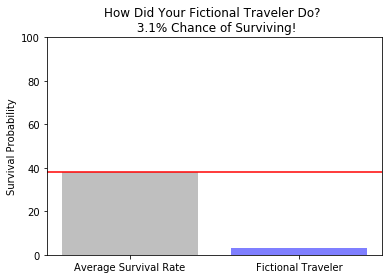

```python
fig = plt.figure()
objects = ('Average Survival Rate', 'Fictional Traveler')
y_pos = np.arange(len(objects))
performance = [average_survival_rate, probability_of_surviving_fictional_character]

ax = fig.add_subplot(111)
colors = ['gray', 'blue']
plt.bar(y_pos, performance, align='center', color = colors, alpha=0.5)
plt.xticks(y_pos, objects)
plt.axhline(average_survival_rate, color="r")
plt.ylim([0,100])
plt.ylabel('Survival Probability')
plt.title('How Did Your Fictional Traveler Do? \n ' + str(round(probability_of_surviving_fictional_character,2)) + '% Chance of Surviving!')

plt.show()
```

## Preparing data set for the cloud and making it pandas free!

```python
titanic_df = pd.read_csv('http://biostat.mc.vanderbilt.edu/wiki/pub/Main/DataSets/titanic3.csv')

# get title
titanic_df['title'] = [ln.split()[1] for ln in titanic_df['name'].values]
titanic_df['title'] = [title if title in ['Mr.', 'Miss.', 'Mrs.', 'Master.', 'Dr.', 'Rev.'] else 'Unknown'
                   for title in titanic_df['title'].values ]

# strip first letter from cabin number if there
titanic_df['cabin'] = titanic_df['cabin'].replace(np.NaN, 'U')
titanic_df['cabin'] = [ln[0] for ln in titanic_df['cabin'].values]
titanic_df['cabin'] = titanic_df['cabin'].replace('U', 'Unknown')

titanic_df['isfemale'] = np.where(titanic_df['sex'] == 'female', 1, 0)

# drop features not needed for model
titanic_df = titanic_df[[f for f in list(titanic_df) if f not in ['sex', 'name', 'boat','body', 'ticket', 'home.dest']]]

# make pclass actual categorical column
titanic_df['pclass'] = np.where(titanic_df['pclass'] == 1, 'First',
                            np.where(titanic_df['pclass'] == 2, 'Second', 'Third'))

# get average survival rate
average_survival_rate = np.mean(titanic_df['survived']) * 100

titanic_df['embarked'] = titanic_df['embarked'].replace(np.NaN, 'Unknown')

# prepare training data
titanic_ready_df = prepare_data_for_model(titanic_df, target_columns=['pclass', 'cabin', 'embarked', 'title'])
titanic_ready_df = titanic_ready_df.dropna()

# save dataframe without header or index
titanic_ready_df.to_csv('titanic3.csv', header=False, index=False)
```

```python
# load the data as an array instead of a data frame
from numpy import genfromtxt
titanic_array = genfromtxt('titanic3.csv', delimiter=',')
```

```python
# split data into train and test portions and model
from sklearn.model_selection import train_test_split

X_train, X_test, y_train, y_test = train_test_split([item[1:] for item in titanic_array],
                                                 [item[0] for item in titanic_array],
                                                 test_size=0.5,
                                                 random_state=42)
```

```python
from sklearn.linear_model import LogisticRegression
lr_model = LogisticRegression()
lr_model.fit(X_train, y_train)
```

```
LogisticRegression(C=1.0, class_weight=None, dual=False, fit_intercept=True,
          intercept_scaling=1, max_iter=100, multi_class='ovr', n_jobs=1,
          penalty='l2', random_state=None, solver='liblinear', tol=0.0001,
          verbose=0, warm_start=False)
```

```python
# let's check that our model works by feeding an array instead of a dataframe
average_survival_rate = np.mean([item[0] for item in titanic_array])

X_train, X_test, y_train, y_test = train_test_split([item[1:] for item in titanic_array],
                                             [item[0] for item in titanic_array],
                                             test_size=0.5,
                                             random_state=42)


# fit model only once
lr_model.fit(X_train, y_train)
```

```
LogisticRegression(C=1.0, class_weight=None, dual=False, fit_intercept=True,
          intercept_scaling=1, max_iter=100, multi_class='ovr', n_jobs=1,
          penalty='l2', random_state=None, solver='liblinear', tol=0.0001,
          verbose=0, warm_start=False)
```

```python
# check that we can get the average survival rate without pandas
np.mean([item[0] for item in titanic_array])
```

```
0.40861244019138754
```

## Let's build out web application!

Building a Flask application is super easy. Make sure you have Flask insalled on your machine along with scikit-learn. You will need to recreate the following file structre (see the video for more details).

web-application/

├── main.py

├── titanic3.csv

├── templates/

```
└── index.html
```

├── static/

```
└── images/

    ├── small_titanic.png

    └── small_cabin_location.png
```

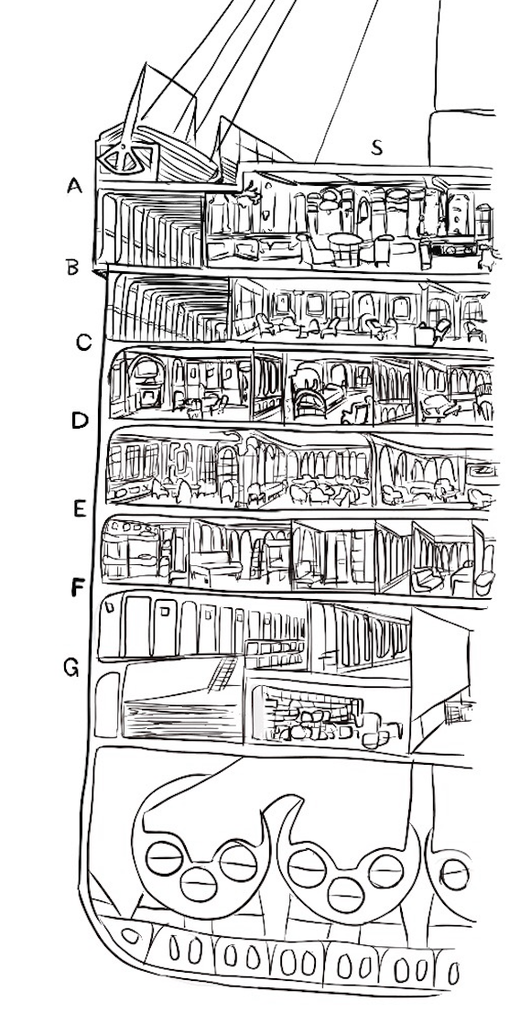

```python
from IPython.display import Image
Image(filename='small_cabin_location.png')
```

[figure not shown]

```python
from IPython.display import Image
Image(filename='small_titanic.png')
```

main.py

```
#!/usr/bin/env python
from flask import Flask, render_template, flash, request, jsonify, Markup
import matplotlib
matplotlib.use('Agg')
import matplotlib.pyplot as plt
import io, base64, os
import numpy as np
from sklearn.linear_model import LogisticRegression
from sklearn.model_selection import train_test_split


# default traveler constants
DEFAULT_EMBARKED = 'Southampton'
DEFAULT_FARE = 33
DEFAULT_AGE = 30
DEFAULT_GENDER = 'Female'
DEFAULT_TITLE = 'Mrs.'
DEFAULT_CLASS = 'Second'
DEFAULT_CABIN = 'C'
DEFAULT_SIBSP = 0
DEFAULT_PARCH = 0

# initializing constant vars
average_survival_rate = 0
# logistic regression modeling
lr_model = LogisticRegression()

app = Flask(__name__)


@app.before_first_request
def startup():
    global average_survival_rate, lr_model

    from numpy import genfromtxt
    titanic_array = genfromtxt('titanic3.csv', delimiter=',')
    average_survival_rate = (np.mean([item[0] for item in titanic_array]) * 100)

    X_train, X_test, y_train, y_test = train_test_split([item[1:] for item in titanic_array],
                                                 [item[0] for item in titanic_array], test_size=0.5, random_state=42)


    # fit model only once
    lr_model.fit(X_train, y_train)

@app.route("/", methods=['POST', 'GET'])
def submit_new_profile():
    model_results = ''
    if request.method == 'POST':
        selected_embarked = request.form['selected_embarked']
        selected_fare = request.form['selected_fare']
        selected_age = request.form['selected_age']
        selected_gender = request.form['selected_gender']
        selected_title = request.form['selected_title']
        selected_class = request.form['selected_class']
        selected_cabin = request.form['selected_cabin']
        selected_sibsp = request.form['selected_sibsp']
        selected_parch = request.form['selected_parch']

        # assign new variables to live data for prediction
        age = int(selected_age)
        isfemale = 1 if selected_gender == 'Female' else 0
        sibsp = int(selected_sibsp)
        parch = int(selected_parch)
        fare = int(selected_fare)

        # point of embarcation
        embarked_Q = 1
        embarked_S = 0
        embarked_Unknown = 0
        embarked_nan = 0
        if (selected_embarked[0]=='Q'):
            embarked_Q = 1
        if (selected_embarked[0]=='S'):
            embarked_S = 1

        # class
        pclass_Second = 0
        pclass_Third = 0
        pclass_nan = 0
        if (selected_class=='Second'):
            pclass_Second = 0
        if (selected_class=='Third'):
            pclass_Third = 0

        # title
        title_Master = 0
        title_Miss = 0
        title_Mr = 0
        title_Mrs = 0
        title_Rev = 0
        title_Unknown = 0
        title_nan = 0
        if (selected_title=='Master.'):
            title_Master = 1
        if (selected_title=='Miss.'):
            title_Miss = 1
        if (selected_title=='Mr.'):
            title_Mr = 1
        if (selected_title=='Mrs.'):
            title_Mrs = 1
        if (selected_title=='Rev.'):
            title_Master = 1
        if (selected_title=='Unknown'):
            title_Unknown = 1

        # cabin
        cabin_B = 0
        cabin_C = 0
        cabin_D = 0
        cabin_E = 0
        cabin_F = 0
        cabin_G = 0
        cabin_T = 0
        cabin_Unknown = 0
        cabin_nan = 0
        if (selected_cabin=='B'):
            cabin_B = 1
        if (selected_cabin=='C'):
            cabin_C = 1
        if (selected_cabin=='D'):
            cabin_D = 1
        if (selected_cabin=='E'):
            cabin_E = 1
        if (selected_cabin=='F'):
            cabin_F = 1
        if (selected_cabin=='G'):
            cabin_G = 1
        if (selected_cabin=='T'):
            cabin_T = 1
        if (selected_cabin=='Unknown'):
            cabin_Unknown = 1

        # build new array to be in same format as modeled data so we can feed it right into the predictor
        user_designed_passenger = [[age, sibsp, parch, fare, isfemale, pclass_Second, pclass_Third, pclass_nan, cabin_B, cabin_C, cabin_D, cabin_E, cabin_F, cabin_G, cabin_T, cabin_Unknown, cabin_nan, embarked_Q, embarked_S, embarked_Unknown, embarked_nan, title_Master, title_Miss, title_Mr, title_Mrs, title_Rev, title_Unknown, title_nan]]


        # add user desinged passenger to predict function
        Y_pred = lr_model.predict_proba(user_designed_passenger)
        probability_of_surviving_fictional_character = Y_pred[0][1] * 100

        fig = plt.figure()
        objects = ('Average Survival Rate', 'Fictional Traveler')
        y_pos = np.arange(len(objects))
        performance = [average_survival_rate, probability_of_surviving_fictional_character]

        ax = fig.add_subplot(111)
        colors = ['gray', 'blue']
        plt.bar(y_pos, performance, align='center', color = colors, alpha=0.5)
        plt.xticks(y_pos, objects)
        plt.axhline(average_survival_rate, color="r")
        plt.ylim([0,100])
        plt.ylabel('Survival Probability')
        plt.title('How Did Your Fictional Traveler Do? \n ' + str(round(probability_of_surviving_fictional_character,2)) + '% of Surviving!')
        img = io.BytesIO()
        plt.savefig(img, format='png')
        img.seek(0)
        plot_url = base64.b64encode(img.getvalue()).decode()

        return render_template('index.html',
            model_results = model_results,
            model_plot = Markup('<img src="data:…">'.format(plot_url)),
            selected_embarked = selected_embarked,
            selected_fare = selected_fare,
            selected_age = selected_age,
            selected_gender = selected_gender,
            selected_title = selected_title,
            selected_class = selected_class,
            selected_cabin = selected_cabin,
            selected_sibsp = selected_sibsp,
            selected_parch = selected_parch)
    else:
        # set default passenger settings
        return render_template('index.html',
            model_results = '',
            model_plot = '',
            selected_embarked = DEFAULT_EMBARKED,
            selected_fare = DEFAULT_FARE,
            selected_age = DEFAULT_AGE,
            selected_gender = DEFAULT_GENDER,
            selected_title = DEFAULT_TITLE,
            selected_class = DEFAULT_CLASS,
            selected_cabin = DEFAULT_CABIN,
            selected_sibsp = DEFAULT_SIBSP,
            selected_parch = DEFAULT_PARCH)

if __name__=='__main__':
    app.run(debug=False)
```

index.html

```
<!DOCTYPE html>
<html>
<head>
    <meta name="viewport" content="width=device-width, initial-scale=1">
    <meta charset="UTF=8">
    <title>Titanic Journey Simulation</title>
</head>

<script src="//ajax.googleapis.com/ajax/libs/jquery/1.9.1/jquery.min.js"></script>
<link rel="stylesheet" href="//netdna.bootstrapcdn.com/bootstrap/3.0.3/css/bootstrap-theme.min.css">
<link rel="stylesheet" href="//netdna.bootstrapcdn.com/bootstrap/3.0.3/css/bootstrap.min.css">
<script src="//netdna.bootstrapcdn.com/bootstrap/3.0.3/js/bootstrap.min.js"></script>

<body>
<div class="container">

<form id='submit_params' method="POST" action="{{ url_for('submit_new_profile') }}">
<div class="form-group">
<table class="table">
    <tr>
        <td width="300px"><p style="text-align:center"><h1>Chapter 3<BR>Design Your Titanic Traveler</h1></p></td>
        <td><p style="text-align:center">
            <img src="static/images/small_titanic.png" alt="titanic" style='padding:1px; border:1px solid #021a40; width: 80%; height: 80%'>
            </p>
        </td>
        <td width="200px"><p style="text-align:center"><h3>Cabin and Port of Embarcation Details</h3></p></td>
    </tr>
    <tr>
        <td>
            <table class="table" border=0 >
                <tr>
                    <td><label for="male">Port of Embarcation</label></td>
                    <td>
                     <SELECT class="selectpicker" name="selected_embarked">
                          <option value="{{selected_embarked}}" selected>{{selected_embarked}}</option>
                          <option>Cherbourg</option>
                          <option>Queenstown</option>
                          <option>Southampton</option>
                      </SELECT>
                    </td>
                </tr>
                <tr>
                    <td><label for="male">Fare</label></td>
                    <td><input type="number" class="form-control" id="fare"
                        placeholder="Enter fare" name="selected_fare" value="{{selected_fare}}">
                    </td>
                </tr>
                <tr>
                    <td><label for="male">Age</label></td>
                    <td>
                       <SELECT class="selectpicker" name="selected_age">
                        <option value="{{selected_age}}" selected>{{selected_age}}</option>
                       {% for age in range(0,100) %}
                           <option>{{age}}</option>
                       {% endfor %}
                        </SELECT>
                    </td>
                </tr>
                <tr>
                    <td><label for="male">Gender</label></td>
                    <td>
                     <SELECT class="selectpicker" name="selected_gender">
                          <option value="{{selected_gender}}" selected>{{selected_gender}}</option>
                          <option value='Male'>Male</option>
                          <option value='Female'>Female</option>
                      </SELECT>
                    </td>
                </tr>
                <tr>
                    <td><label for="male">Title</label></td>
                    <td>
                     <SELECT class="selectpicker" name="selected_title">
                        <option value="{{selected_title}}" selected>{{selected_title}}</option>
                        <option value="Dr.">Dr.</option>
                        <option value="Master.">Master.</option>
                        <option value="Miss.">Miss.</option>
                        <option value="Mr.">Mr.</option>
                        <option value="Mrs.">Mrs.</option>
                        <option value="Master.">Master.</option>
                        <option value="Unknown.">Unknown</option>
                        <option value="Rev.">Rev.</option>
                      </SELECT>
                    </td>
                </tr>
                <tr>
                    <td><label for="male">Class</label></td>
                    <td>
                     <SELECT class="selectpicker" name="selected_class">
                        <option value="{{selected_class}}" selected>{{selected_class}}</option>
                        <option value='First'>First</option>
                        <option value='Second'>Second</option>
                        <option value='Third'>Third</option>
                    </td>
                </tr>
                <tr>
                    <td><label for="male">Cabin</label></td>
                    <td>
                     <SELECT class="selectpicker" name="selected_cabin">
                        <option value="{{selected_cabin}}" selected>{{selected_cabin}}</option>
                        <option>A</option>
                        <option>B</option>
                        <option>C</option>
                        <option>D</option>
                        <option>E</option>
                        <option>F</option>
                        <option>G</option>
                        <option>T</option>
                        <option>Unknown</option>
                    </td>
                </tr>
                <tr>
                    <td><label for="male">Number of Siblings/Spouses</label></td>
                    <td>
                        <SELECT class="selectpicker" name="selected_sibsp">
                        <option value="{{selected_sibsp}}" selected>{{selected_sibsp}}</option>
                       {% for sibsp in range(0,10) %}
                           <option>{{sibsp}}</option>
                       {% endfor %}
                        </SELECT>
                    </td>
                </tr>
                <tr>
                    <td><label for="male">Number of Parents/Children</label></td>
                    <td>
                        <SELECT class="selectpicker" name="selected_parch">
                        <option value="{{selected_parch}}" selected>{{selected_parch}}</option>
                       {% for parch in range(0,10) %}
                           <option>{{parch}}</option>
                       {% endfor %}
                        </SELECT>
                    </td>
                </tr>

          </table>

        </td>

        <td>{{model_results}}<BR>{{model_plot}}
        </td>
        <td>
            <p style="text-align:center">Cabin Key</p>
            <p style="text-align:center">
            <img src="static/images//small_cabin_location.png" alt="cabin locations" style='padding:1px; border:1px solid #021a40; width: 100%; height: 100%'>
            </p></td>
    </tr>
    <td><button class="btn btn-default" type="submit" style="width: 100px; height: 30px;">All Aboard!</button></td><td></td><td></td>
    <tr>
</table>
</div>
</form>

</div>
</body>
</html>
```

Manuel Amunategui - Follow me on Twitter: @amunategui